# Predicting the 2021 D1 Lacrosse National Championship Using ELO

### Tucker Siegel

Inspired by Nate Silver at FiveThirtyEight, who has built ELO based systems for rating sports teams in the NFL, NBA, WNBA, etc. ELO essentially boils down to comparing teams and changing the rating of the team based on prior victories and losses. They then use monte carlo simulations (random simulations) to estimate future wins and losses. So could we use the same system and apply is to college lacrosse to predict the winner of the national championship, or at least get percentage chances of each team winning? This could be useful because if the modeling method is successful in Lacrosse, it may work for college basketball (with some modifications)

Quick explanation of ELO: the system is used in chess to rate players, by transfering points from the loser to the winner, with dimishing returns. That indicates there is a theoretical maximum that is decided by the parameters of the system. The main parameter for ELO is the K factor, which is essentially how volatile the system is. High K means it will move more points than a lower K. Here (https://medium.com/purple-theory/what-is-elo-rating-c4eb7a9061e0) is a good, more indepth explanation.

Sidenote - Why use monte carlo simulations? Well this is because monte carlo simulations have been shown to be able to model a complex system that could have enourmous (like 10e20) number of events. That number is very difficult to calculate, however randomly sampling a certain number of those events (which is calculated through random chance at every step in the simulation), a very reasonable result can be found.

```python
!pip install tqdm
import requests
from bs4 import BeautifulSoup
import pandas as pd
import numpy as np
import random, sys
from tqdm.autonotebook import tqdm
from scipy import optimize
import matplotlib.pyplot as plt
url = "https://www.insidelacrosse.com/league/DI/teams"
r = requests.get(url)
soup = BeautifulSoup(r.content, 'html5lib')

tournament_start_date = "05/15/2021"
tournament_start_date = pd.to_datetime(tournament_start_date)
```

# Data Collection

We need yearly data that has the schedule of every D1 team, to be able to train our data on. We are using insidelacrosse.com to get the data

```python
# this function will connect to insidelacrosse.com, and will pull the data for whatever year
# indicated and dump that into a dataframe

def pull_season(year=2021, verbose=False, verbose_top_level=False):
    if (verbose and verbose_top_level):
        raise ValueError("Cannot have both verbose.")
    tables = soup.find("div", attrs={"class": "col-xs-12 col-md-6 col-lg-5"})

    conference_df = pd.DataFrame(columns=('conference', 'team'))
    games_df = pd.DataFrame(columns=("date", "home_team", "away_team", "home_score", "away_score", "winner", "home_win"))

    indexer_top = tqdm(tables.findAll("table")) if verbose_top_level else tables.findAll("table")
    for table in indexer_top:
        conference = table.find("th", attrs={"class": "text-xs-center", "colspan": "10"}).text

        if verbose:
            print ("Processing %s" % conference)
        conference = conference.lower().replace(" ", "_")

        indexer = tqdm(table.findAll("a")) if verbose else table.findAll("a")
        for team in indexer:

            row_to_add = pd.Series({"conference": conference, "team": team.text})
            conference_df = conference_df.append(row_to_add,ignore_index=True)

            team_data_url = "https://www.insidelacrosse.com" + team["href"]
            team_data_url = "/".join(team_data_url.split("/")[:-1]) + "/" + str(year)

            team_data = requests.get(team_data_url)
            td_soup = BeautifulSoup(team_data.content, 'html5lib')
            try:
                schedy = td_soup.find("div", attrs={"class": "col-xs-12 col-lg-5 col-xl-4 pull-lg-left"}).div.tbody
            except:
                continue

            if (schedy == None):
                continue

            for game in schedy.findAll("tr"):
                _team = team.text
                date = game.td.text + "/" + str(year)
                opponent = game.td.find_next("td").text
                home_away = "away" if "@" in opponent else "home"
                opponent = opponent.replace("@", "").replace("vs", "").strip()

                if _team in ignore or opponent in ignore:
                    continue

                w_l = game.td.find_next("td").find_next("td").text
                score = game.td.find_next("td").find_next("td").find_next("td").text
                if "-" not in score:
                    continue
                home_score = int(score.split("-")[0])
                away_score = int(score.split("-")[1])

                home_team = _team if home_away == "home" else opponent
                away_team = opponent if home_away == "home" else _team

                # this allows us to find duplicate games, because we get the same game from both teams schedule
                check = games_df[(games_df["away_team"] == away_team) & (games_df["home_team"] == home_team) &
                                 (games_df["date"] == date)]
                if len(check) != 0:
                    continue

                winner = _team if w_l == "W" else opponent

                home_win = 1 if winner == home_team else 0


                row_to_add = pd.Series({"home_team": home_team, "away_team": away_team,
                                        "home_score": home_score, "away_score": away_score,
                                       "date": date, "winner": winner, "home_win": home_win, "season": year})

                games_df = games_df.append(row_to_add,ignore_index=True)



    games_df["date"] = pd.to_datetime(games_df["date"])
    return conference_df, games_df
```

```python
conference_df, games_df = pull_season(year=2021, verbose=True)

# since we only want games pre-2021 tournament, we need to cut off the extra
pre_tournament = games_df[games_df["date"] < tournament_start_date]
pre_tournament
```

```
Processing ACC
```

```
Processing America East
```

```
Processing Big East
```

```
Processing Big Ten
```

```
Processing CAA
```

```
Processing DI Independent
```

```
Processing Ivy League
```

```
Processing MAAC
```

```
Processing NEC
```

```
Processing Patriot
```

```
Processing SoCon
```

|  | date | home_team | away_team | home_score | away_score | winner | home_win | season |
| --- | --- | --- | --- | --- | --- | --- | --- | --- |
| 0 | 2021-02-05 | Duke | Denver | 12 | 10 | Duke | 1 | 2021.0 |
| 1 | 2021-02-07 | Duke | Robert Morris | 16 | 12 | Duke | 1 | 2021.0 |
| 2 | 2021-02-13 | Duke | Mercer | 17 | 8 | Duke | 1 | 2021.0 |
| 3 | 2021-02-20 | Towson | Duke | 7 | 19 | Duke | 0 | 2021.0 |
| 4 | 2021-02-27 | Duke | Air Force | 17 | 7 | Duke | 1 | 2021.0 |
| ... | ... | ... | ... | ... | ... | ... | ... | ... |
| 379 | 2021-05-01 | Bellarmine | Mercer | 11 | 8 | Bellarmine | 1 | 2021.0 |
| 380 | 2021-03-09 | Bellarmine | VMI | 12 | 8 | Bellarmine | 1 | 2021.0 |
| 381 | 2021-03-27 | Bellarmine | Air Force | 6 | 8 | Air Force | 0 | 2021.0 |
| 382 | 2021-04-10 | VMI | Bellarmine | 9 | 11 | Bellarmine | 0 | 2021.0 |
| 383 | 2021-04-17 | Air Force | VMI | 18 | 4 | Air Force | 1 | 2021.0 |

378 rows × 8 columns

```python
# lets get the rest of the seasons. The data only goes back as far as 2014
print ("running 2020")
_, games_2020 = pull_season(year=2020, verbose=False, verbose_top_level=True)
print ("running 2019")
_, games_2019 = pull_season(year=2019, verbose=False, verbose_top_level=True)
print ("running 2018")
_, games_2018 = pull_season(year=2018, verbose=False, verbose_top_level=True)
print ("running 2017")
_, games_2017 = pull_season(year=2017, verbose=False, verbose_top_level=True)
print ("running 2016")
_, games_2016 = pull_season(year=2016, verbose=False, verbose_top_level=True)
print ("running 2015")
_, games_2015 = pull_season(year=2015, verbose=False, verbose_top_level=True)
print ("running 2014")
_, games_2014 = pull_season(year=2014, verbose=False, verbose_top_level=True)

# we need to drop LIU and Merrimack from the data from before 2020 because they were d2 at that point
games_2019 = games_2019[(games_2019["home_team"] != "Merrimack") & (games_2019["home_team"] != "LIU")]
games_2018 = games_2018[(games_2018["home_team"] != "Merrimack") & (games_2018["home_team"] != "LIU")]
games_2017 = games_2017[(games_2017["home_team"] != "Merrimack") & (games_2017["home_team"] != "LIU")]
games_2016 = games_2016[(games_2016["home_team"] != "Merrimack") & (games_2016["home_team"] != "LIU")]
games_2015 = games_2015[(games_2015["home_team"] != "Merrimack") & (games_2015["home_team"] != "LIU")]
games_2014 = games_2014[(games_2014["home_team"] != "Merrimack") & (games_2014["home_team"] != "LIU")]

games_2019 = games_2019[(games_2019["away_team"] != "Merrimack") & (games_2019["away_team"] != "LIU")]
games_2018 = games_2018[(games_2018["away_team"] != "Merrimack") & (games_2018["away_team"] != "LIU")]
games_2017 = games_2017[(games_2017["away_team"] != "Merrimack") & (games_2017["away_team"] != "LIU")]
games_2016 = games_2016[(games_2016["away_team"] != "Merrimack") & (games_2016["away_team"] != "LIU")]
games_2015 = games_2015[(games_2015["away_team"] != "Merrimack") & (games_2015["away_team"] != "LIU")]
games_2014 = games_2014[(games_2014["away_team"] != "Merrimack") & (games_2014["away_team"] != "LIU")]
```

```
running 2020
```

```
running 2019
```

```
running 2018
```

```
running 2017
```

```
running 2016
```

```
running 2015
```

```
running 2014
```

# Data Managment

So this part we will be doing some data modification, because the data we really care about is the ELO. Below includes some helper functions and classes that will aid in that

```python
# this function will calculate the winning percentage a team has, and then using the inverse of the formula that is used
# to calculate win probability, we can calculate home field advantage in terms of ELO

def get_home_field_advantage(games):

    home_wins = len(all_games[all_games["home_win"] == 1])
    all_game_count = len(all_games)
    hfa_pct = home_wins/all_game_count
    hfa = -400 * np.log((1/hfa_pct) - 1)
    hfa /= np.log(10)

    return hfa
```

```python
# define a simple tournament and game set class to help manage everything
class Tournament():

    def __init__(self, matchups):
        self.matchups = matchups
        self.winner = None
        self.in_progress = None
        self.completed = []
        self.elos = {}

    def get_next_game(self):
        x = self.matchups[0]
        del self.matchups[0]
        self.in_progress = x
        return x

    def set_winner(self, winner, e1, e2):
        self.completed.append((self.in_progress, winner))
        self.elos[self.in_progress[0]] = e1
        self.elos[self.in_progress[1]] = e2
        if len(self.matchups) == 0:
            self.winner = winner
            return
        if len(self.matchups[-1]) == 1:
            self.matchups[-1].append(winner)
        else:
            self.matchups.append([winner])

class GameSet():

    def __init__(self, matchups):
        self.matchups = matchups
        self.completed = []
        self.elos = {}

    def get_next_game(self):
        x = self.matchups[0]
        del self.matchups[0]
        self.in_progress = x
        return x

    def set_winner(self, winner, e1, e2):
        self.completed.append((self.in_progress, winner))
        self.elos[self.in_progress[0]] = e1
        self.elos[self.in_progress[1]] = e2
```

```python
class Model():

    # The data is the data to be trained on. Elo base is the base elo each team will be initialized to.
    # hfa is home field advantage (in elo), k_factor is the k factor explained above, and the season change is
    # a parameter effecting the strength of regression after a season

    def __init__(self, data, elo_base=1500,hfa=40, k_factor=30, season_change=0.666):
        self.elo_base = 1500
        self.elo_tracker = pd.DataFrame(columns=("season", "date", "team", "old_elo", "new_elo", "change"))
        self.data = data
        self.hfa = hfa
        self.season_change = season_change
        self.k_factor = k_factor

        self.elo_dict = {t: elo_base for t in np.unique(data["home_team"].values)}

    # we want to regress ELOs back after every season because things may change during the offseason
    def regress_elo(self):
        self.elo_dict = {i: self.elo_dict[i] * (1 - self.season_change) + 1500 * (self.season_change) for i in self.elo_dict}

    def reset_elo(self):
        self.elo_dict = {t: self.elo_base for t in np.unique(self.data["home_team"].values)}

    # this is essentially the fit funtion. We go through every season, and then every game.
    # at each game, we calculate the home-field advantage adjusted elo difference, then using the standard
    # elo update function, we calculate the percent change a team has to win based on the difference in ELO.
    # It is the same formula used in chess.
    # Following FiveThirtyEight's implementation, we use a function to calculate the impact a goal differential has
    # on ELO. That explanation can be found at https://fivethirtyeight.com/methodology/how-our-nfl-predictions-work/,
    # however it is a diminishing return function, so in the case where a really good team destroys a really bad team,
    # the update is different than a really good team narowly beating a really bad team.
    def step(self, seasons):
        self.reset_elo()
        hfa, k_factor = self.hfa, self.k_factor
        pt_diff = []
        for s in seasons:
            print (s)
            self.regress_elo()
            g_df = self.data[self.data["season"] == s]

            dates = np.unique(g_df["date"].values)
            i = 0
            for date in sorted(dates):
                games_date = g_df[g_df["date"] == date]
                for idx, game in games_date.iterrows():

                    i += 1
                    home_team = game["home_team"]
                    away_team = game["away_team"]

                    row_home = {"season": s, "date": date, "team": home_team}
                    row_away = {"season": s, "date": date, "team": away_team}


                    if (home_team not in self.elo_dict or away_team not in self.elo_dict):
                        continue

                    home_elo = self.elo_dict[home_team]
                    away_elo = self.elo_dict[away_team]

                    row_home["old_elo"] = home_elo
                    row_away["old_elo"] = away_elo

                    elo_diff = home_elo - away_elo + self.hfa

                    elo_prob = 1.0 / (np.power(10.0, (-elo_diff/400.0)) + 1.0)

                    goal_diff = game["home_score"] - game["away_score"]

                    pt_diff.append((home_elo - away_elo)/(goal_diff))


                    mult = np.log(np.clip(abs(goal_diff), 1, 10000)) + 1
                    mult *= (2.2/(elo_diff * 0.001 + 2.2))

                    shift = (k_factor * mult) * (game['home_win'] - elo_prob)

                    home_elo = home_elo + shift
                    away_elo = away_elo - shift

                    row_home["new_elo"] = home_elo
                    row_home["change"] = shift

                    row_away["new_elo"] = away_elo
                    row_away["change"] = -shift

                    self.elo_dict[home_team] = home_elo
                    self.elo_dict[away_team] = away_elo

                    self.elo_tracker = self.elo_tracker.append(row_home,ignore_index=True)
                    self.elo_tracker = self.elo_tracker.append(row_away,ignore_index=True)
        self.elo_to_pts = np.mean(pt_diff)

    def fit(self):

        seasons = self.data["season"].values.tolist()
        seasons = np.unique(seasons)

        self.step(seasons)

    def pull_team_season(self, team, season):
        return self.elo_tracker[(self.elo_tracker["season"] == season) & (self.elo_tracker["team"] == team)]

    # this function gets the rankings at the last day in the dataset
    def get_rankings(self):
        rankings = []
        elo_dict = {k: v for k, v in sorted(self.elo_dict.items(), key=lambda item: item[1])}
        for e in elo_dict:
            rankings.append((e, elo_dict[e]))
        return rankings[::-1]

    # this function checks every game, predicts the winner, and then calculates the average accuracy
    # NOTE: this function is indicative of preformance, however it is not a true indicator because a true
    # indicator would require the model to be trained while it is testing on games, because that is how it
    # works in "production"
    def eval(self, df):
        correct = 0
        total = 0
        df["week"] = df["date"].dt.week

        for idx, g in df.iterrows():
            home_team = g["home_team"]
            away_team = g["away_team"]

            if (home_team not in self.elo_dict or away_team not in self.elo_dict):
                continue

            home_elo = self.elo_dict[home_team]
            away_elo = self.elo_dict[away_team]

            diff = home_elo - away_elo + self.hfa
            win_prob = 1.0 / (np.power(10.0, (-diff/400.0)) + 1.0)

            if win_prob > 0.5:
                home_win = 1
            else:
                home_win = 0
            if home_win == g["home_win"]:
                correct += 1
            total += 1

        return correct/total

    # this takes a list of games and runs a monte carlo simulation using them
    def simulate_games(self, matches, iterations=100):
        self.base_elo = dict(self.elo_dict)
        games = []
        for i in tqdm(range(iterations)):
            t = GameSet(list(matches))
            self.elo_dict = dict(self.base_elo)
            self.inner_simulate(t)

            games.append(t)

        return games

    # same as above, but with support for tiered tournaments
    def simulate_tournament(self, matches, iterations=100):
        self.base_elo = dict(self.elo_dict)
        games = []
        winners = {}
        for i in tqdm(range(iterations)):
            t = Tournament(list(matches))
            self.elo_dict = dict(self.base_elo)
            self.inner_simulate(t)

            games.append(t)

            if t.winner in winners:
                winners[t.winner] += 1/iterations
            else:
                winners[t.winner] = 1/iterations

        self.elo_dict = dict(self.base_elo)

        return games, winners

    # here is the actual simulation. We start by getting the game and the competitors, get a NON HOME FIELD ADVANTAGE
    # difference (because we don't indicate it, and in a tournament it really doesn't matter at all). That difference
    # is used to calculate a win prob, and that is compared to a random epsilon value. If the probability is greater than
    # epsilon, it is considered a home win, and vice versa for away win. Then a spread (goal differential) is calculated
    # using the difference divided by the average ratio of elo diff and points. A randomly generated goal differential is then
    # created, which is then used to update the elo's of each team
    def inner_simulate(self, game_set):

        i = 1
        while len(game_set.matchups) != 0:
            i += 1
            game = game_set.get_next_game()
            team_1 = game[0]
            team_2 = game[1]

            team_1_elo = self.elo_dict[team_1]
            team_2_elo = self.elo_dict[team_2]

            diff = team_1_elo - team_2_elo


            exp_win_prob = 1.0 / (np.power(10.0, (-diff/400.0)) + 1.0)
            eps = random.uniform(0, 1)
            if (eps < exp_win_prob):
                winner = 1
                w_idx = 0
            else:
                winner = 0
                w_idx = 1

            spread = abs(diff / self.elo_to_pts)

            if winner == 1:
                goal_diff = random.randint(1, int(spread) + 1)
            else:
                goal_diff = -random.randint(1, int(spread) + 1)

            mult = np.log(np.clip(abs(goal_diff), 1, 10000)) + 1
            mult *= (2.2/(diff * 0.001 + 2.2))

            shift = (self.k_factor * mult) * (winner - exp_win_prob)

            self.elo_dict[team_1] += shift
            self.elo_dict[team_2] -= shift

            game_set.set_winner(game[w_idx], self.elo_dict[team_1], self.elo_dict[team_2])
```

# EDA + Hypothesis testing and machine learning

Due to the nature of the analysis we are doing, EDA will have to be done after we build a model. Fortunately the model is completely deterministic, so results will not change for each run when we build a new model

Now we get into model training. This is first just so we can see if it is a viable solution

```python
# train a model on data to 2020, test on 2021
frames = [games_2020, games_2019, games_2018, games_2017, games_2016, games_2015, games_2014]
all_games = pd.concat(frames)

hfa = get_home_field_advantage(all_games)

mod = Model(all_games, 1500, hfa=hfa, k_factor=20, season_change=0.3)
mod.fit()
accuracy = mod.eval(pre_tournament)
mod.elo_tracker.tail()

print ("Model accuracy traind on data 2014-2020, tested on 2021:", accuracy)
```

```
2014.0
2015.0
2016.0
2017.0
2018.0
2019.0
2020.0
```

```
Model accuracy traind on data 2014-2020, tested on 2021: 0.7338709677419355
```

lets train a model on data from 2014-2019, but just before the tournament started. Then, we can monte carlo simulate the tournament. Not using 2020 because COVID

```python
# train a model on data to 2020, test on 2021
frames = [games_2019, games_2018, games_2017, games_2016, games_2015, games_2014]
all_games = pd.concat(frames)

tournament_start_2019 = pd.to_datetime("05/11/2019")
tournament_games = all_games[all_games["date"] >= tournament_start_2019]
all_games = all_games[all_games["date"] < tournament_start_2019]

hfa = get_home_field_advantage(all_games)

mod = Model(all_games, 1500, hfa=hfa, k_factor=20, season_change=0.3)
mod.fit()
accuracy = mod.eval(tournament_games)
mod.elo_tracker.tail()
print ("Model accuracy traind on data 2014-2019, tested on 2019 tournament:", accuracy)
```

```
2014.0
2015.0
2016.0
2017.0
2018.0
2019.0
Model accuracy traind on data 2014-2019, tested on 2019 tournament: 0.8
```

```python
# This function will check through the results of a simulation to calculate probabilities of winning the games,
# and return a dataframe with the results.
def run_games(comps, incoming_games):
    out = pd.DataFrame(columns=("team_1", "team_2", "winner", "prob"))
    for g in incoming_games:
        game_check = ([g[0], g[1]], g[0])
        inv_game_check = ([g[0], g[1]], g[1])
        wins = 0
        total = 0
        for c in comps:
            if game_check in c:
                wins += 1
                total += 1
            elif inv_game_check in c:
                total += 1
        ods_home = wins/total * 100

        winner = ""
        prob = 0
        if ods_home > 50:
            winner = g[0]
            prob = ods_home
        else:
            winner = g[1]
            prob = 100 - ods_home

        d = {"team_1": g[0], "team_2": g[1], "winner": winner, "prob": prob}
        out = out.append(d, ignore_index=True)
    return out

# Here we run the simulation. The game structure is taken from https://en.wikipedia.org/wiki/2019_NCAA_Division_I_Men%27s_Lacrosse_Championship
# Run for 1000000 times
tournament_games = tournament_games.sort_values("date")

opening_games = {"home_team": ["Penn State", "Loyola", "Yale", "Penn", "Virginia", "Towson", "Notre Dame", "Duke"],
                 "away_team": ["UMBC", "Syracuse", "Georgetown", "Army", "Robert Morris", "Maryland", "Johns Hopkins", "Richmond"],
                 "winner": ["Penn State", "Loyola", "Yale", "Penn", "Virginia", "Maryland", "Notre Dame", "Duke"]}
opening_games = pd.DataFrame.from_dict(opening_games)
games = []
for idx, g in opening_games.iterrows():
    games.append([g["home_team"], g["away_team"]])

res_games, winners = mod.simulate_tournament(games, iterations=1000000)

# time to check results
comps = [t.completed for t in res_games]

rd1 = run_games(comps, games)

rd2_games = []
for i in range(0, 8, 2):
    rd2_games.append([rd1["winner"].values[i], rd1["winner"].values[i+1]])

rd2 = run_games(comps, rd2_games)


rd3_games = []
for i in range(0, 4, 2):
    rd3_games.append([rd2["winner"].values[i], rd2["winner"].values[i+1]])


rd3 = run_games(comps, rd3_games)

final_games = [[rd3["winner"].values[0], rd3["winner"].values[1]]]

final = run_games(comps, final_games)
```

```python
print (rd1)
print (" ")
print (rd2)
print (" ")
print (rd3)
print (" ")
print (final)
```

```
       team_1         team_2         winner     prob
0  Penn State           UMBC     Penn State  85.7333
1      Loyola       Syracuse         Loyola  51.3650
2        Yale     Georgetown           Yale  68.5047
3        Penn           Army           Penn  58.3529
4    Virginia  Robert Morris       Virginia  66.3163
5      Towson       Maryland       Maryland  57.0603
6  Notre Dame  Johns Hopkins  Johns Hopkins  50.0385
7        Duke       Richmond           Duke  70.8800

          team_1    team_2      winner       prob
0     Penn State    Loyola  Penn State  62.786516
1           Yale      Penn        Yale  67.052742
2       Virginia  Maryland    Maryland  51.756750
3  Johns Hopkins      Duke        Duke  65.195757

       team_1 team_2 winner       prob
0  Penn State   Yale   Yale  50.998336
1    Maryland   Duke   Duke  56.852377

  team_1 team_2 winner       prob
0   Yale   Duke   Yale  57.296483
```

Wow! The model actually preformed very well. The only places that the model had an issue with was when the game probability was roughly 50%. Hopkins vs ND was incorrect, ND actually won that game, however they lose to Duke, same as hopkins in the simulation so the effect is minimal. The Virginia Maryland game in round 2 is also wrong, Virginia won that game, and that issue propogated to the end of the simulation, where Virginia actually made it to the end of the tournament and won in real life (against Yale), however in this case, they lost to Maryland, thus messing up the simulation for the rest of the time.

You can compare your results to the bracket here: https://en.wikipedia.org/wiki/2019_NCAA_Division_I_Men%27s_Lacrosse_Championship#Bracket

# Real machine learning

Now it is time to predict the future. Lets get into it

Before we get into predicting this seasons tournament, lets take a look at the ELO scores for certain teams and try to understand if it is really representative of the team.

First up is UMD. UMD has had an absolutely dominant season, not losing a single game. This would imply the ELO for Maryland would be increasing the entire way. I came to this conclusion by looking at UMD's preformance (shown below).

```python
pre_tournament[(pre_tournament["home_team"] == "Maryland") | (pre_tournament["away_team"] == "Maryland")].sort_values("date")
```

|  | date | home_team | away_team | home_score | away_score | winner | home_win | season | week |
| --- | --- | --- | --- | --- | --- | --- | --- | --- | --- |
| 142 | 2021-02-20 | Maryland | Michigan | 20 | 9 | Maryland | 1 | 2021.0 | 7 |
| 143 | 2021-02-26 | Penn State | Maryland | 7 | 13 | Maryland | 0 | 2021.0 | 8 |
| 144 | 2021-03-06 | Maryland | Johns Hopkins | 18 | 10 | Maryland | 1 | 2021.0 | 9 |
| 145 | 2021-03-13 | Maryland | Rutgers | 19 | 12 | Maryland | 1 | 2021.0 | 10 |
| 146 | 2021-03-20 | Ohio State | Maryland | 8 | 16 | Maryland | 0 | 2021.0 | 11 |
| 147 | 2021-03-28 | Rutgers | Maryland | 9 | 13 | Maryland | 0 | 2021.0 | 12 |
| 148 | 2021-04-03 | Maryland | Penn State | 17 | 10 | Maryland | 1 | 2021.0 | 13 |
| 149 | 2021-04-10 | Michigan | Maryland | 12 | 18 | Maryland | 0 | 2021.0 | 14 |
| 150 | 2021-04-18 | Maryland | Ohio State | 18 | 8 | Maryland | 1 | 2021.0 | 15 |
| 151 | 2021-04-24 | Johns Hopkins | Maryland | 13 | 14 | Maryland | 0 | 2021.0 | 16 |
| 152 | 2021-05-06 | Maryland | Michigan | 16 | 8 | Maryland | 1 | 2021.0 | 18 |
| 153 | 2021-05-08 | Maryland | Johns Hopkins | 12 | 10 | Maryland | 1 | 2021.0 | 18 |

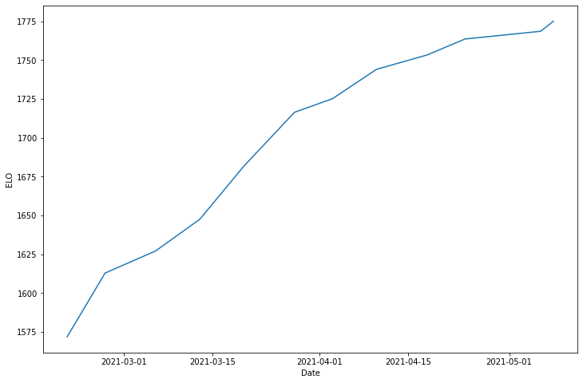

```python
# Lets look at UMD's elo change over the season
umd_elo_track = mod.pull_team_season("Maryland", 2021)
x = umd_elo_track["new_elo"].values
fig = plt.figure(figsize=(12, 8))
ax = fig.add_subplot(111)
ax.set_xlabel("Date")
ax.set_ylabel("ELO")
ax.plot(umd_elo_track["date"].values, umd_elo_track["new_elo"].values)
```

That assumption was correct, the ELO is showing correctly. Next is JHU, who had a decent start to their season, followed by a falling off, and then a steep turn around at the end. I expect the graph to be increasing somewhat in the beginning, followed by a massive fall off, and the steep incline at the end. Below is hopkins actual preformance:

```python
pre_tournament[(pre_tournament["home_team"] == "Johns Hopkins") | (pre_tournament["away_team"] == "Johns Hopkins")].sort_values("date")
```

|  | date | home_team | away_team | home_score | away_score | winner | home_win | season | week |
| --- | --- | --- | --- | --- | --- | --- | --- | --- | --- |
| 164 | 2021-02-20 | Johns Hopkins | Ohio State | 8 | 14 | Ohio State | 0 | 2021.0 | 7 |
| 176 | 2021-02-27 | Michigan | Johns Hopkins | 7 | 14 | Johns Hopkins | 0 | 2021.0 | 8 |
| 144 | 2021-03-06 | Maryland | Johns Hopkins | 18 | 10 | Maryland | 1 | 2021.0 | 9 |
| 171 | 2021-03-13 | Johns Hopkins | Penn State | 13 | 6 | Johns Hopkins | 1 | 2021.0 | 10 |
| 157 | 2021-03-20 | Johns Hopkins | Rutgers | 9 | 15 | Rutgers | 0 | 2021.0 | 11 |
| 173 | 2021-03-28 | Penn State | Johns Hopkins | 11 | 8 | Penn State | 1 | 2021.0 | 12 |
| 177 | 2021-04-04 | Johns Hopkins | Michigan | 10 | 13 | Michigan | 0 | 2021.0 | 13 |
| 168 | 2021-04-10 | Ohio State | Johns Hopkins | 14 | 12 | Ohio State | 1 | 2021.0 | 14 |
| 160 | 2021-04-17 | Rutgers | Johns Hopkins | 17 | 11 | Rutgers | 1 | 2021.0 | 15 |
| 151 | 2021-04-24 | Johns Hopkins | Maryland | 13 | 14 | Maryland | 0 | 2021.0 | 16 |
| 175 | 2021-05-01 | Penn State | Johns Hopkins | 7 | 15 | Johns Hopkins | 0 | 2021.0 | 17 |
| 162 | 2021-05-06 | Rutgers | Johns Hopkins | 10 | 12 | Johns Hopkins | 0 | 2021.0 | 18 |
| 153 | 2021-05-08 | Maryland | Johns Hopkins | 12 | 10 | Maryland | 1 | 2021.0 | 18 |

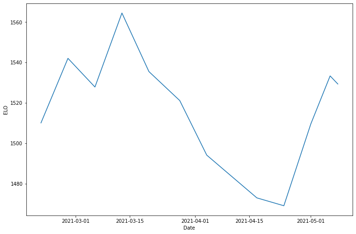

```python
# We also know that John's Hopkins made a major turn around towards the end of the season
jhu_elo_track = mod.pull_team_season("Johns Hopkins", 2021)
x = jhu_elo_track["new_elo"].values
fig = plt.figure(figsize=(12, 8))
ax = fig.add_subplot(111)
ax.set_xlabel("Date")
ax.set_ylabel("ELO")
ax.plot(jhu_elo_track["date"].values, jhu_elo_track["new_elo"].values)
```

Time to simulate the tournament. Lets start with possible winner projections and the probability of winning.

```python
# need to train a model that reflects all the way up to the beginning of the tournament
frames = [pre_tournament, games_2020, games_2019, games_2018, games_2017, games_2016, games_2015, games_2014]
all_games = pd.concat(frames)

mod = Model(all_games, 1500, hfa=hfa, k_factor=20, season_change=0.3)
mod.fit()

res_games, winners = mod.simulate_tournament([["North Carolina", "Monmouth"], ["Lehigh", "Rutgers"],
                                   ["Georgetown", "Syracuse"], ["Virginia", "Bryant"],
                                   ["Maryland", "Vermont"], ["Notre Dame", "Drexel"],
                                   ["Denver", "Loyola"], ["Duke", "High Point"]], iterations=100000)



winners = {k: v for k, v in sorted(winners.items(), key=lambda item: item[1])}
for w in list(winners.keys())[::-1]:
    print (w, winners[w])
```

```
2014.0
2015.0
2016.0
2017.0
2018.0
2019.0
2020.0
2021.0
```

```
Maryland 0.19222000000005146
North Carolina 0.18069000000003993
Georgetown 0.11312999999998884
Duke 0.10834999999999069
Denver 0.09014999999999775
Virginia 0.055710000000006386
Notre Dame 0.05307000000000558
Lehigh 0.04051000000000173
Drexel 0.034669999999999944
Loyola 0.029259999999998978
Rutgers 0.026659999999999084
Syracuse 0.026439999999999093
Vermont 0.01619999999999951
Bryant 0.01592999999999952
High Point 0.012799999999999647
Monmouth 0.004209999999999997
```

This shows that Maryland has the best chance at winning the tournament, with a 19% chance. North Carolina is just behind at 18%

```python
comps = [t.completed for t in res_games]

rd1 = run_games(comps, [["North Carolina", "Monmouth"], ["Lehigh", "Rutgers"],
                                   ["Georgetown", "Syracuse"], ["Virginia", "Bryant"],
                                   ["Maryland", "Vermont"], ["Notre Dame", "Drexel"],
                                   ["Denver", "Loyola"], ["Duke", "High Point"]])

rd2_games = []
for i in range(0, 8, 2):
    rd2_games.append([rd1["winner"].values[i], rd1["winner"].values[i+1]])

rd2 = run_games(comps, rd2_games)


rd3_games = []
for i in range(0, 4, 2):
    rd3_games.append([rd2["winner"].values[i], rd2["winner"].values[i+1]])


rd3 = run_games(comps, rd3_games)

final_games = [[rd3["winner"].values[0], rd3["winner"].values[1]]]

final = run_games(comps, final_games)
```

```python
print (rd1)
print (" ")
print (rd2)
print (" ")
print (rd3)
print (" ")
print (final)
```

```
           team_1      team_2          winner    prob
0  North Carolina    Monmouth  North Carolina  83.673
1          Lehigh     Rutgers          Lehigh  53.526
2      Georgetown    Syracuse      Georgetown  65.581
3        Virginia      Bryant        Virginia  63.025
4        Maryland     Vermont        Maryland  75.601
5      Notre Dame      Drexel      Notre Dame  54.388
6          Denver      Loyola          Denver  62.653
7            Duke  High Point            Duke  72.093

           team_1      team_2          winner       prob
0  North Carolina      Lehigh  North Carolina  65.541415
1      Georgetown    Virginia      Georgetown  58.728435
2        Maryland  Notre Dame        Maryland  64.887729
3          Denver        Duke            Duke  50.889041

           team_1      team_2          winner       prob
0  North Carolina  Georgetown  North Carolina  53.219523
1        Maryland        Duke        Maryland  58.058028

           team_1    team_2    winner       prob
0  North Carolina  Maryland  Maryland  54.988532
```

And there you have it. My predictions indicate that UMD will be the winner of the 2021 college lacrosse championships.

# Communication of insights attained

So what have we done here? What does this analysis show? Well the analysis actually shows a lot. We learned that we can use a system built for a no score, zero sum game like chess and apply it to a complex sport like college lacrosse, with little modification. We also show that sports are actually far more quantifiable than once realized, however there are still little things that are seemingly up to random chance, like an underdog coming out of nowhere to win a big game.

Also, we know UMD is going to win the 2021 lacrosse national championship. Go Terps!